# E-NEWS EXPRESS PROJECT

By:Sushma Rao

# Start by importing the required libraries

```python
#import the important packages
import numpy as np
import pandas as pd

# import the required function
from statsmodels.stats.proportion import proportions_ztest
# import libraries for data visualization
import matplotlib.pyplot as plt
import seaborn as sns
```

# Define the problem and perform an Exploratory Data Analysis

.The online News portal wants to expand its business by acquiring new subscribers.

.Every visitor to the website takes certain actions based on their interest.

.The company wants to determine whether a new feature will be effective or not.

.Company has introduced a new variant, and it wants to analyze user’s responses to two variants of a product to decide which of the two variants is more effective.

# Data Dictionary:

```
user_id - This represents the user ID of the person visiting the website.

group - This represents whether the user belongs to the first group (control) or the second group (treatment).

landing_page - This represents whether the landing page is new or old.

time_spent_on_the_page - This represents the time (in minutes) spent by the user on the landing page.

converted - This represents whether the user gets converted to a subscriber of the news portal or not.

language_preferred - This represents the language chosen by the user to view the landing page.
```

.Here we have a sample data set ,which has two categories in the group attribute ,which shows the CONTROL group, which used an old landing page and the TREATMENT group which used the new landing page.

.Divide the data set into two, one for the control group and the other for the treatment group , and then perform the hypothesis testing at a significance level of 5%.

# Reading the data into a dataframe

```python
#reading the abtest.csv file
df = pd.read_csv('abtest.csv')
```

# Understanding the structure of the data

```python
# first five rows of the dataset
df.head()
```

|  | user_id | group | landing_page | time_spent_on_the_page | converted | language_preferred |
| --- | --- | --- | --- | --- | --- | --- |
| 0 | 546592 | control | old | 3.48 | no | Spanish |
| 1 | 546468 | treatment | new | 7.13 | yes | English |
| 2 | 546462 | treatment | new | 4.40 | no | Spanish |
| 3 | 546567 | control | old | 3.02 | no | French |
| 4 | 546459 | treatment | new | 4.75 | yes | Spanish |

```python
# shape of the dataset
df.shape
```

```
(100, 6)
```

There are 100 rows and 6 columns

```python
# information about the columns in the data
df.info()
```

```
<class 'pandas.core.frame.DataFrame'>
RangeIndex: 100 entries, 0 to 99
Data columns (total 6 columns):
 #   Column                  Non-Null Count  Dtype
---  ------                  --------------  -----
 0   user_id                 100 non-null    int64
 1   group                   100 non-null    object
 2   landing_page            100 non-null    object
 3   time_spent_on_the_page  100 non-null    float64
 4   converted               100 non-null    object
 5   language_preferred      100 non-null    object
dtypes: float64(1), int64(1), object(4)
memory usage: 4.8+ KB
```

User id and time spent on the page are numerical variables and the rest are categorical variables.

```python
# check for missing values
df.isnull().sum()
```

```
user_id                   0
group                     0
landing_page              0
time_spent_on_the_page    0
converted                 0
language_preferred        0
dtype: int64
```

There are no missing Values

```python
df['group'].value_counts()#finding the number of values in the control and treatment group
```

```
treatment    50
control      50
Name: group, dtype: int64
```

The data set can be divided into 2 data sets for doing our hypothesis testing ,the two data sets have same number of values.

```python
df.describe()# finding the central tendency
```

|  | user_id | time_spent_on_the_page |
| --- | --- | --- |
| count | 100.000000 | 100.000000 |
| mean | 546517.000000 | 5.377800 |
| std | 52.295779 | 2.378166 |
| min | 546443.000000 | 0.190000 |
| 25% | 546467.750000 | 3.880000 |
| 50% | 546492.500000 | 5.415000 |
| 75% | 546567.250000 | 7.022500 |
| max | 546592.000000 | 10.710000 |

# Univariate and Bivariate Analysis

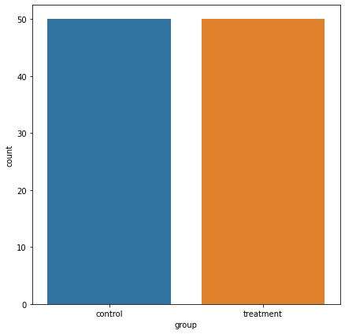

```python
# visual analysis of outputs from control group and treatment group
plt.figure(figsize=(7,7))
sns.countplot(data= df,x="group")
df['group'].value_counts(normalize=True)
plt.show()
```

The size of the control and the treatment group is (50*6)

```
group
control      4.5324
treatment    6.2232
Name: time_spent_on_the_page, dtype: float64
```

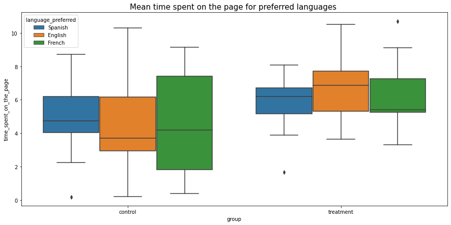

```python
#Visualization for the time spent on the page based on the type of the group for all the preferred languages.
print(df.groupby("group")["time_spent_on_the_page"].mean())

# draw the boxplot for visualization
fig, ax = plt.subplots(figsize = (15,7))
a = sns.boxplot(x= "group", y = 'time_spent_on_the_page' , data = df, hue = 'language_preferred')
a.set_title("Mean time spent on the page for preferred languages ", fontsize=15)
plt.show()
```

# Observation

```
. The mean time spent on the new landing page (treatment group)is more than the Control group.
.The treatment group looks independent of the preferred languages.
```

# Forming A and B groups from the given data set to perform A/B testing

```python
#forming Variation B group ,which is the treatment group
df_new=df[df['group']=='treatment']#df_new is a dataset with only information about the new landing page(treatment group)
```

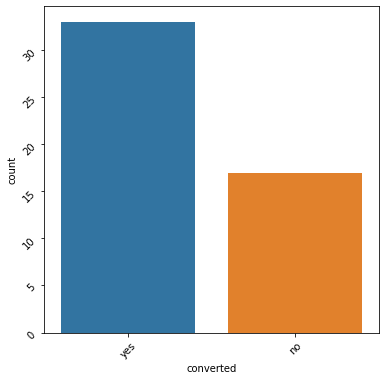

```python
#Visual Analysis of converted status for the Variation B group(treatment group)
plt.figure(figsize=(6,6))
sns.countplot(data= df_new,x="converted")
df['converted'].value_counts(normalize=True)
plt.xticks(rotation=45)
plt.yticks(rotation=45)# To rotate the x axis labls
plt.show()
```

# Observation

More number of visitors, who visited the new landing page converted their status .the conversion rate is more.

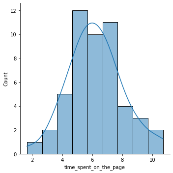

```python
#plotting the density curve for the treatment page
sns.displot(df_new,x='time_spent_on_the_page',kde=True)
```

Observation:It is a Normal distribution.

```python
#forming Variation A group ,which is the control group(old landing page)
df_old=df[df['group']=='control']
```

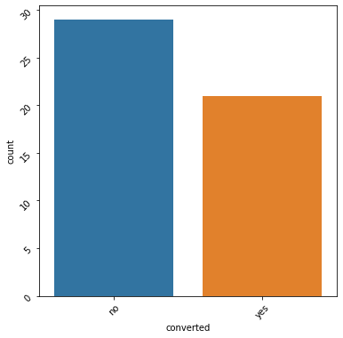

```python
#Visual analysis of the converted status for the Variation A group(control group)
plt.figure(figsize=(6,6))
sns.countplot(data= df_old,x="converted")
df['converted'].value_counts(normalize=True)
plt.xticks(rotation=45)
plt.yticks(rotation=45)# To rotate the x axis labls
plt.show()
```

# Observation

Less number of people converted their status on visiting the old landing page.the conversion rate is less.

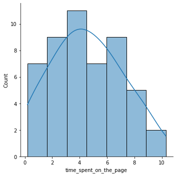

```python
#plotting the density curve for the control page
sns.displot(df_old ,x='time_spent_on_the_page',kde=True)
```

Observation: The distribution is not Normal ,it looks like it is right skewed.

# Illustrate the insights based on EDA

# Observation:

```
1.The mean time spent is more on the treatment group than the control group.
2.The conversion rate is also high in the case of treatment group.
3.The treatment group distribution is normal.
4.The treatment group also looks independent of the preferred Languages.
```

Overall new landing page looks to perform better than the old one, which has to be statistically proven by doing certain hypothesis tests.

# Do the users spend more time on the new landing page than the old landing page?

# Let's write the null and alternative hypothesis

Let 𝜇1 be the mean delivery time of the time spent on the new page and 𝜇2 be the time spent on the old page respectively. We will test the null hypothesis

𝐻0:𝜇1= 𝜇2

against the alternate hypothesis

𝐻𝑎:𝜇1> 𝜇2

```python
# find the sample means and sample standard deviations for the two samples
print('The mean time spent on the new page is ' + str(df_new['time_spent_on_the_page'].mean()))
print('The mean time spent on the old page is ' + str(df_old['time_spent_on_the_page'].mean()))
print('The standard deviation of time spent on the new page is ' + str(round(df_new['time_spent_on_the_page'].std(), 2)))
print('The standard deviation of time spent on the old page is ' + str(round(df_old['time_spent_on_the_page'].std(), 2)))
```

```
The mean time spent on the new page is 6.2232
The mean time spent on the old page is 4.532400000000001
The standard deviation of time spent on the new page is 1.82
The standard deviation of time spent on the old page is 2.58
```

# Let's test whether the T-test assumptions are satisfied or not

Continuous data - Yes, the time spent is measured on a continuous scale.

Normally distributed populations - Yes, we are informed that the populations are assumed to be normal as the sample size is 50.

Independent populations - As we are taking random samples for two different groups, the two samples are from two independent populations.

Unequal population standard deviations - As the sample standard deviations are different, the population standard deviations may be assumed to be different.

Random sampling from the population - Yes, we are informed that the collected sample a simple random sample.

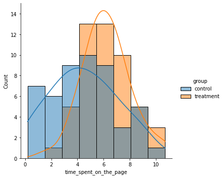

```python
#Visual analysis of the time spent for both the groups
sns.displot(df,x='time_spent_on_the_page',hue='group',kde=True)
```

Observation: The treatment group density curve is normal.

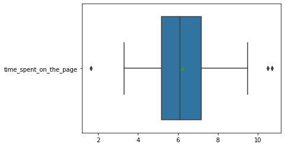

```python
#Visual analysis of the time spent on the new landing page using boxplot
sns.boxplot(data=df_new[["group","time_spent_on_the_page"]],orient="h",showmeans=True)
```

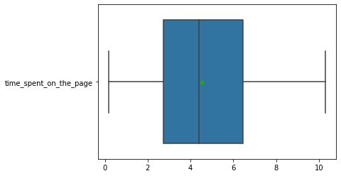

```python
#Visual analysis of the time spent on the old landing page using boxplot
sns.boxplot(data=df_old[["group","time_spent_on_the_page"]],orient="h",showmeans=True)
```

Observation: The visual analysis shows that the time spent on the new landing page is more that of the old landing page.

# Calulate the P-Value ,The level of Significance is 5%.

It is a one tailed test, so we choose the alternative to be greater.

```python
#import the required functions
from scipy.stats import ttest_ind

# find the p-value
test_stat, p_value = ttest_ind(df_new['time_spent_on_the_page'], df_old['time_spent_on_the_page'].dropna(), equal_var = False, alternative = 'greater')
print('The p-value is ', p_value)
```

```
The p-value is  0.0001392381225166549
```

# Compare the p-value with 𝛼

```python
# print the conclusion based on p-value
if p_value < 0.05:
    print(f'As the p-value {p_value} is less than the level of significance, we reject the null hypothesis.')
else:
    print(f'As the p-value {p_value} is greater than the level of significance, we fail to reject the null hypothesis.')
```

```
As the p-value 0.0001392381225166549 is less than the level of significance, we reject the null hypothesis.
```

# Insight

As the p-value (0.0001) is less than the level of significance, we can reject the null hypothesis. Hence, we do have enough evidence to support the claim that the mean time spent on the new landing page is more than that of the old landing page.

# Is the conversion rate (the proportion of users who visit the landing page and get converted) for the new page greater than the conversion rate for the old page?

# Let's write the null and alternative hypothesis

Let 𝑝1,𝑝2 be the proportions of conversion for the new landing page and old landing page respectively.

Then News portal will test the null hypothesis

𝐻0:𝑝1=𝑝2

against the alternate hypothesis

𝐻𝑎:𝑝1 != 𝑝2

```
yes    54
no     46
Name: converted, dtype: int64
```

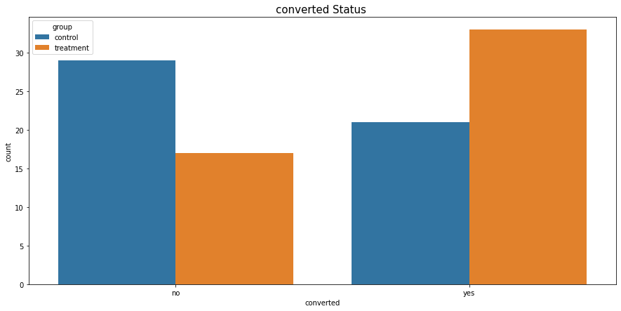

```python
print(df["converted"].value_counts())


# draw the boxplot for visualization
fig, ax = plt.subplots(figsize = (15,7))
a = sns.countplot(x= "converted", data = df, hue = 'group')
a.set_title("converted Status ", fontsize=15)
plt.show()
```

observation: The proportion of people who got converted is more in the treatment group.

# Let's test whether the Z-test assumptions are satisfied or not

Binomally distributed population - Yes,converted is (yes or no)

Random sampling from the population - Yes, we are informed that the collected sample is a simple random sample.

```python
df_old['converted'].value_counts()#number of people converted in the control group(old)
```

```
no     29
yes    21
Name: converted, dtype: int64
```

```python
conv_rate_old=21/50#conversion rate of the control group
conv_rate_old
```

```
0.42
```

```python
df_new['converted'].value_counts()#number of people converted in the treatmrnt group(new)
```

```
yes    33
no     17
Name: converted, dtype: int64
```

```python
conv_rate_new=33/50#conversion rate of the new group
conv_rate_new
```

```
0.66
```

# Calulate the P-Value ,The level of Significance is 5%.

```python
# import the required fuction
from statsmodels.stats.proportion import proportions_ztest

# set the converted array
con_count = np.array([33, 21])

# set the sample sizes
n = np.array([50, 50])

# find the p-value
test_stat, p_value = proportions_ztest(con_count, n)
print('The p-value is ' + str(p_value))
```

```
The p-value is 0.016052616408112556
```

# Compare the p-value with 𝛼

```python
# print the conclusion based on p-value
if p_value < 0.05:
    print(f'As the p-value {p_value} is less than the level of significance, we reject the null hypothesis.')
else:
    print(f'As the p-value {p_value} is greater than the level of significance, we fail to reject the null hypothesis.')
```

```
As the p-value 0.016052616408112556 is less than the level of significance, we reject the null hypothesis.
```

# Insight

As the p-value (0.016) is less than the level of significance, we can reject the null hypothesis. Hence, we do not have enough evidence to support that the proportion of people converted is same in both the cases.

here, the conversion rate (the proportion of users who visit the landing page and get converted) for the new page(66%) is greater than the conversion rate for the old page(42%).

# Does the converted status depend on the preferred language?

# Chi-Square Test for Independence

# Let's write the null and alternative hypothesis

We will test the null hypothesis

𝐻0:

Converted status is independent on the preferred language, against the alternate hypothesis

𝐻𝑎:

Converted status is dependent on the preferred language.

# Let's test whether the assumptions are satisfied or not

Categorical variables - Yes

Expected value of the number of sample observations in each level of the variable is at least 5 - Yes, the number of observations in each level is greater than 5.

Random sampling from the population - Yes, we are informed that the collected sample is a simple random sample.

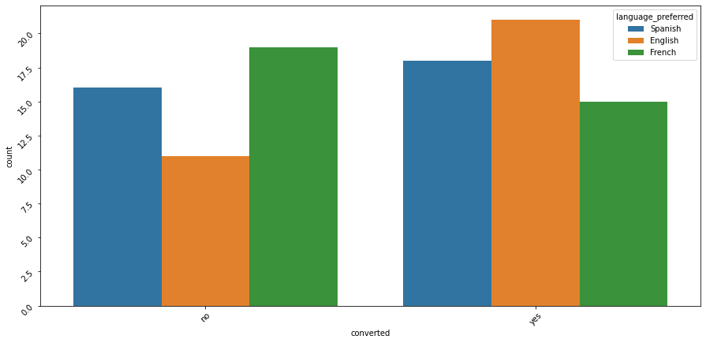

```python
#analysing the dataset given:which includes both control and treatment group
#visual Analysis of converted status for different language preferrence .
plt.figure(figsize=(15,7))
sns.countplot(data= df,x="converted",hue='language_preferred')
df['converted'].value_counts(normalize=True)
plt.xticks(rotation=45)
plt.yticks(rotation=45)# To rotate the x axis labls
plt.show()
```

observation: the plot shows no significant dependence between the coverted and language preferred.

```python
# constructing the crosstable for the original dataset
ct_original=pd.crosstab(df.language_preferred,df.converted=='yes')
ct_original
```

| converted language_preferred | False | True |
| --- | --- | --- |
| English | 11 | 21 |
| French | 19 | 15 |
| Spanish | 16 | 18 |

```python
#Finding the test statistic,pvalue and the degrees of freedom
import scipy.stats as stats
stats.chi2_contingency(ct_original)
```

```
(3.0930306905370832,
 0.2129888748754345,
 2,
 array([[14.72, 17.28],
        [15.64, 18.36],
        [15.64, 18.36]]))
```

# Find the p-value

```python
# import the required function
from scipy.stats import chi2_contingency

# find the p-value
chi, p_value, dof, expected = chi2_contingency(ct_original)
print('The p-value is', p_value)
```

```
The p-value is 0.2129888748754345
```

# Compare the p-value with 𝛼

```python
# print the conclusion based on p-value
if p_value < 0.05:
    print(f'As the p-value {p_value} is less than the level of significance, we reject the null hypothesis.')
else:
    print(f'As the p-value {p_value} is greater than the level of significance, we fail to reject the null hypothesis.')
```

```
As the p-value 0.2129888748754345 is greater than the level of significance, we fail to reject the null hypothesis.
```

# INSIGHT:

we fail to reject the null hypothesis,we do not have enough evidence to say that converted status depends on the language preferred.

```python
#Creating the crosstable for the converted status for the control group
ct_old=pd.crosstab(df_old.language_preferred,df_old.converted=='yes')
ct_old
```

| converted language_preferred | False | True |
| --- | --- | --- |
| English | 5 | 11 |
| French | 14 | 3 |
| Spanish | 10 | 7 |

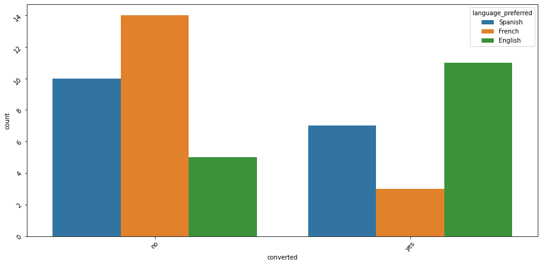

```python
#analysing the dataset of control  group
#visual Analysis of converted status for different language preferrence .
plt.figure(figsize=(15,7))
sns.countplot(data= df_old,x="converted",hue='language_preferred')
df['converted'].value_counts(normalize=True)
plt.xticks(rotation=45)
plt.yticks(rotation=45)# To rotate the x axis labls
plt.show()
```

observation: The conversion rate is less in the control group

# Find the P-Value

```python
# import the required function
from scipy.stats import chi2_contingency

# find the p-value
chi, p_value, dof, expected = chi2_contingency(ct_old)
print('The p-value is', p_value)
```

```
The p-value is 0.012013484079071492
```

# Compare the p-value with 𝛼

```python
# print the conclusion based on p-value
if p_value < 0.05:
    print(f'As the p-value {p_value} is less than the level of significance, we reject the null hypothesis.')
else:
    print(f'As the p-value {p_value} is greater than the level of significance, we fail to reject the null hypothesis.')
```

```
As the p-value 0.012013484079071492 is less than the level of significance, we reject the null hypothesis.
```

INSIGHT: we have evidence to show that the converted status of the control group depends on the language preferred.

```python
#Creating the crosstable for the converted status for the treatment group
ct_new=pd.crosstab(df_new.language_preferred,df_new.converted=='yes')
ct_new
```

| converted language_preferred | False | True |
| --- | --- | --- |
| English | 6 | 10 |
| French | 5 | 12 |
| Spanish | 6 | 11 |

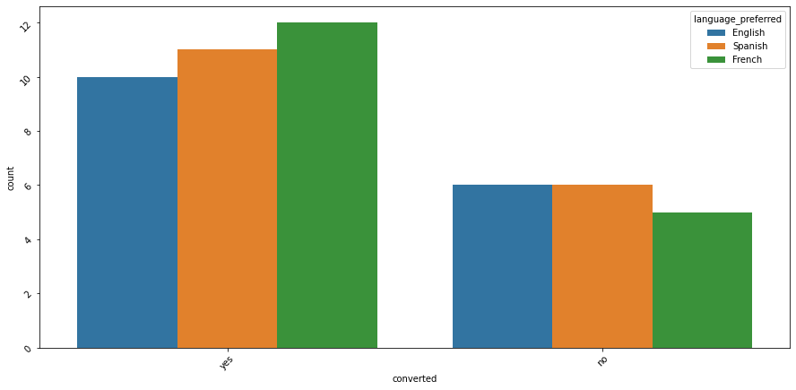

```python
#analysing the dataset of treatment  group
#visual Analysis of converted status for different language preferrence .
plt.figure(figsize=(15,7))
sns.countplot(data= df_new,x="converted",hue='language_preferred')
df['converted'].value_counts(normalize=True)
plt.xticks(rotation=45)
plt.yticks(rotation=45)# To rotate the x axis labls
plt.show()
```

Observation:The conversion rate is high

# Find the P-Value

```python
# import the required function
from scipy.stats import chi2_contingency

# find the p-value
chi, p_value, dof, expected = chi2_contingency(ct_new)
print('The p-value is', p_value)
```

```
The p-value is 0.8783081441552572
```

# Compare the p-value with 𝛼

```python
# print the conclusion based on p-value
if p_value < 0.05:
    print(f'As the p-value {p_value} is less than the level of significance, we reject the null hypothesis.')
else:
    print(f'As the p-value {p_value} is greater than the level of significance, we fail to reject the null hypothesis.')
```

```
As the p-value 0.8783081441552572 is greater than the level of significance, we fail to reject the null hypothesis.
```

# INSIGHT:

```
we fail to reject the null hypothesis,we do not have enough evidence to show that converted status depends on
language preferred.
```

# Is the mean time spent on the new page same for the different language users?

# The null and alternative hypothesis for one way ANOVA test

Let 𝜇1,𝜇2,𝜇3

be the means of time spent on the new landing page based on the languages Spanish,French and English respectively. We will test the null hypothesis

```
𝐻0:𝜇1=𝜇2=𝜇3
```

against the alternative hypothesis

```
𝐻𝑎:
```

At least one mean time is different from the rest.

```python
df_new['language_preferred'].value_counts()#number of preferred languages for the new page
```

```
Spanish    17
French     17
English    16
Name: language_preferred, dtype: int64
```

```python
df1_spanish=df_new[df_new['language_preferred']=='Spanish']# filtering the dataset having only spanish
df1_spanish.head()
```

|  | user_id | group | landing_page | time_spent_on_the_page | converted | language_preferred |
| --- | --- | --- | --- | --- | --- | --- |
| 2 | 546462 | treatment | new | 4.40 | no | Spanish |
| 4 | 546459 | treatment | new | 4.75 | yes | Spanish |
| 12 | 546491 | treatment | new | 5.86 | yes | Spanish |
| 15 | 546466 | treatment | new | 6.27 | yes | Spanish |
| 24 | 546456 | treatment | new | 6.18 | no | Spanish |

```python
df1_spanish['time_spent_on_the_page'].mean()# find the mean time spent on the page for spanish language
```

```
5.835294117647059
```

```python
df1_french=df_new[df_new['language_preferred']=='French']# filtering the dataset having only French
df1_french.head()
```

|  | user_id | group | landing_page | time_spent_on_the_page | converted | language_preferred |
| --- | --- | --- | --- | --- | --- | --- |
| 6 | 546448 | treatment | new | 5.25 | yes | French |
| 8 | 546461 | treatment | new | 10.71 | yes | French |
| 13 | 546478 | treatment | new | 6.03 | yes | French |
| 28 | 546471 | treatment | new | 7.81 | yes | French |
| 46 | 546460 | treatment | new | 5.37 | yes | French |

```python
df1_french['time_spent_on_the_page'].mean()# find the mean time spent on the page for french language
```

```
6.196470588235294
```

```python
df1_English=df_new[df_new['language_preferred']=='English']# filtering the dataset having only English
df1_English.head()
```

|  | user_id | group | landing_page | time_spent_on_the_page | converted | language_preferred |
| --- | --- | --- | --- | --- | --- | --- |
| 1 | 546468 | treatment | new | 7.13 | yes | English |
| 16 | 546443 | treatment | new | 8.73 | no | English |
| 22 | 546450 | treatment | new | 3.65 | no | English |
| 23 | 546475 | treatment | new | 7.02 | yes | English |
| 25 | 546455 | treatment | new | 4.39 | no | English |

```python
df1_English['time_spent_on_the_page'].mean()# find the mean time spent on the page for English language
```

```
6.6637499999999985
```

```python
# import libraries for data visualization
import matplotlib.pyplot as plt
import seaborn as sns
```

```
language_preferred
English    6.663750
French     6.196471
Spanish    5.835294
Name: time_spent_on_the_page, dtype: float64
```

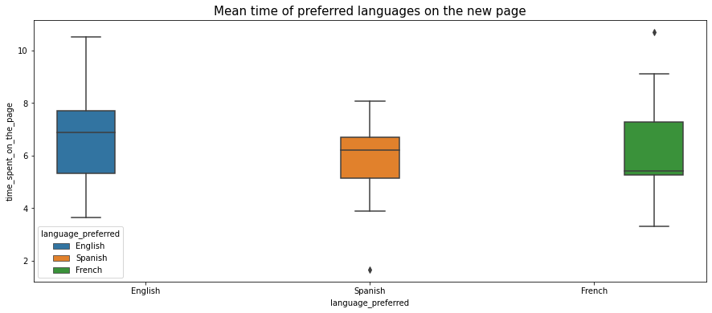

```python
#visual Analysis of the mean time spent by the treatment group for different languages
print(df_new.groupby("language_preferred")["time_spent_on_the_page"].mean())

# draw the boxplot for visualization
fig, ax = plt.subplots(figsize = (15,6))
a = sns.boxplot(x= "language_preferred", y = 'time_spent_on_the_page' , data = df_new, hue = 'language_preferred')
a.set_title("Mean time of preferred languages on the new page", fontsize=15)
plt.show()
```

# The normality and equality of variance assumptions need to be checked.

```
For testing of normality, Shapiro-Wilk’s test is applied to the response variable.

For equality of variance, Levene test is applied to the response variable.
```

# Shapiro-Wilk’s test

We will test the null hypothesis

```
𝐻0:

time spent on the page follows a normal distribution against
```

against the alternative hypothesis

```
𝐻𝑎:
```

time spent on the page does not follow a normal distribution

```python
# Assumption 1: Normality
# import the required function
from scipy import stats

# find the p-value
w, p_value = stats.shapiro(df_new['time_spent_on_the_page'])
print('The p-value is', p_value)
```

```
The p-value is 0.8040016293525696
```

Let's test whether the assumptions are satisfied or not

[output not shown]

# Levene’s test

We will test the null hypothesis

```
𝐻0

: All the population variances are equal
```

against the alternative hypothesis

```
𝐻𝑎
```

: At least one variance is different from the rest

```python
#Assumption 2: Homogeneity of Variance
#import the required function
from scipy.stats import levene
statistic, p_value = levene( df_new.loc[df_new['language_preferred'] == 'Spanish', 'time_spent_on_the_page'],
                              df_new.loc[df_new['language_preferred'] == 'French', 'time_spent_on_the_page'],
                              df_new.loc[df_new['language_preferred'] == 'English', 'time_spent_on_the_page'])
# find the p-value
print('The p-value is', p_value)
```

```
The p-value is 0.46711357711340173
```

Since the p-value is large, we fail to reject the null hypothesis of homogeneity of variances.

# Let's test whether the assumptions are satisfied or not

```
The populations are normally distributed - Yes, the normality assumption is verified using the Shapiro-Wilk’s test.
Samples are independent simple random samples - Yes, we are informed that the collected sample is a simple random sample.
Population variances are equal - Yes, the homogeneity of variance assumption is verified using the Levene's test.
```

# Find the P-Value

```python
#import the required function
from scipy.stats import f_oneway

# perform one-way anova test
test_stat, p_value = f_oneway(df_new.loc[df_new['language_preferred'] == 'Spanish', 'time_spent_on_the_page'],
                              df_new.loc[df_new['language_preferred'] == 'French', 'time_spent_on_the_page'],
                              df_new.loc[df_new['language_preferred'] == 'English', 'time_spent_on_the_page'])
print('The p-value is ' + str(p_value))
```

```
The p-value is 0.43204138694325955
```

# Compare the p-value with 𝛼

```python
# print the conclusion based on p-value
if p_value < 0.05:
    print(f'As the p-value {p_value} is less than the level of significance, we reject the null hypothesis.')
else:
    print(f'As the p-value {p_value} is greater than the level of significance, we fail to reject the null hypothesis.')
```

```
As the p-value 0.43204138694325955 is greater than the level of significance, we fail to reject the null hypothesis.
```

# Insight

As the p-value is greater than the significance level, we fail to reject the null hypothesis. Hence, we do not have enough evidence to conclude that at least one mean time spent on the page by one of the 3 languages is different from the rest at 5% significance level.

hence, we can say the mean time spent on the new page for different language users is almost the same.

# Conclusions Based on the Statistical Analysis and Hypothesis testing

The goal of the online E-news Express company is to expand their business by acquiring new customers.The desing team of the company has designed a new landing page. The task of the Data Scientist is to do statistical anlaysis based on the sample data set provided , to know the performance of the new landing page .The aim is to give insights on which page performs better.

The data set is divided into Variation A (control group,old landing page) and Variation B (treatment group, new landing page). Various hypothesis testings are done, based on which the following conclusions can be drawn:

1.The Average or mean time spent on the New landing page is greater than the old landing page.

2.The Conversion rate of the New landing page is more than the old landing page.

4.The average or the mean time spent on the new landing page for different languages (Spanish,French,English) is almost the same . The time spent on the new landing page is independent of the language preferred.

# Recommendation to Business

New Landing page is more effective than the old Landing page based on all the Statistical Analysis done . New landing page can help the company to attract new subscribers.